# Lab 5: One-Sample t-Test Answers

## 1 Preliminaries

```r
library(tidyverse)  # for data wrangling and visualization
library(psych)      # for describe() and scoreItems()
library(janitor)    # for frequency and contingency tables
library(broom)      # for tidy t-test output
library(papaja)     # for APA style output
library(lsr)        # for cohensD()
library(BrailleR)   # for accessibility
GoBlind()
```

## 2 Data

```r
df <- read_csv('data/tworek2016_study2.csv') %>%
  as_tibble() %>%
  select(diff, excluded) %>%
  filter(excluded == 0)
glimpse(df)
```

```
Rows: 112
Columns: 2
$ diff     <dbl> -0.1333333, 0.6666667, 5.0000000, 2.9333333, 0.5333333, 1.600…
$ excluded <dbl> 0, 0, 0, 0, 0, 0, 0, 0, 0, 0, 0, 0, 0, 0, 0, 0, 0, 0, 0, 0, 0…
```

```r
describe(df) %>%
  knitr::kable()
```

|  | vars | n | mean | sd | median | trimmed | mad | min | max | range | skew | kurtosis | se |
| --- | --- | --- | --- | --- | --- | --- | --- | --- | --- | --- | --- | --- | --- |
| diff | 1 | 112 | 0.6482143 | 1.741588 | 0.5333333 | 0.6592593 | 1.33434 | -5.4 | 7.6 | 13 | -0.0582586 | 3.63934 | 0.1645646 |
| excluded | 2 | 112 | 0.0000000 | 0.000000 | 0.0000000 | 0.0000000 | 0.00000 | 0.0 | 0.0 | 0 | NaN | NaN | 0.0000000 |

## 3 Check Assumptions

### 3.1 Normality

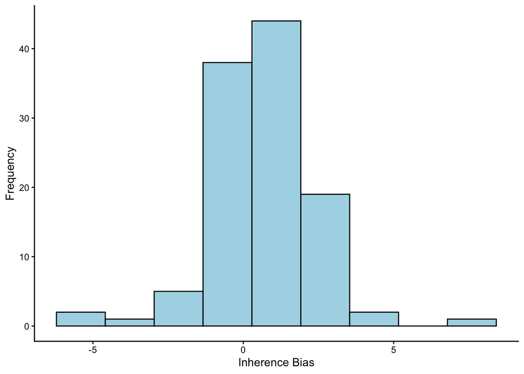

```
This is an untitled chart with no subtitle or caption.
It has x-axis 'Inherence Bias' with labels -5, 0 and 5.
It has y-axis 'Frequency' with labels 0, 10, 20, 30 and 40.
The chart is a bar chart with 9 vertical bars.
Bar 1 is centered at -5.4, and length is from 0 to 2.
Bar 2 is centered at -3.78, and length is from 0 to 1.
Bar 3 is centered at -2.15, and length is from 0 to 5.
Bar 4 is centered at -0.53, and length is from 0 to 38.
Bar 5 is centered at 1.1, and length is from 0 to 44.
Bar 6 is centered at 2.72, and length is from 0 to 19.
Bar 7 is centered at 4.35, and length is from 0 to 2.
Bar 8 is centered at 5.97, and length is from 0 to 0.
Bar 9 is centered at 7.6, and length is from 0 to 1.
It has colour set to black.
It has fill set to very light greenish blue.
```

```r
df %>%
    ggplot(aes(x = diff)) +
    geom_histogram(bins = 9, color = "black", fill = "lightblue") +
    labs(x = "Inherence Bias", y = "Frequency") +
    theme_classic()
```

```r
shapiro.test(df$diff)
```

```
    Shapiro-Wilk normality test

data:  df$diff
W = 0.92506, p-value = 9.343e-06
```

## 4 One-Sample t-Test

```r
res_t <- t.test(df$diff,
                mu = 0,
                alternative = "two.sided")
res_t
```

```
    One Sample t-test

data:  df$diff
t = 3.939, df = 111, p-value = 0.0001433
alternative hypothesis: true mean is not equal to 0
95 percent confidence interval:
 0.3221185 0.9743101
sample estimates:
mean of x
0.6482143
```

**CautionCommon Mistake: Baseline (null mean)**

Our baseline changed now that our DV is a “relative” preference score. The baseline is now 0, not 5. Make sure you run the t-test using the correct baseline by putting that value in the `mu` argument.

```r
res_apa <- res_t %>%
   apa_print()
res_apa$full_result
```

```
[1] "$M = 0.65$, 95\\% CI $[0.32, 0.97]$, $t(111) = 3.94$, $p < .001$"
```

*M* = 0.65, 95% CI $[0.32, 0.97]$, *t*(111) = 3.94, *p* < .001

### 4.1 Effect Size (Cohen’s d)

```r
d <- cohensD(df$diff, mu = 0)
d
```

```
[1] 0.3721972
```

**CautionCommon Mistake: Baseline (null mean) for Cohen’s d**

Our baseline changed now that our DV is a “relative” preference score. The baseline is now 0, not 5. Make sure you calculate Cohen’s d using the correct baseline by putting that value in the `mu` argument.

## 5 Write up the results

> A one-sample t-test was performed to compare the mean relative preference of inherent over extrinsic explanation to the baseline of 0. The mean preference was significantly above the baseline, *M* = 0.65, 95% CI $[0.32, 0.97]$, *t*(111) = 3.94, *p* < .001, with a small effect size, d = 0.37. These results suggest that there is a small but significant tendency to prefer inherent over extrinsic explanations.

**CautionCommon Mistakes: Baseline**

- “the scale midpoint of 0”

Our baseline is no longer the scale midpoint of 5. The baseline is now 0, because we are using a “relative” preference score. Make sure you report the correct baseline in your write-up.

**CautionCommon Mistakes: Not Reporting the Direction of the Effect**

Note that, although the test was two-tailed, you state that the sample mean was significantly **above** the baseline. If you just said that the sample mean was significantly different from the baseline, that’s not that informative. Readers may be left unsatisfied, wondering if the sample mean was higher or lower than the baseline. Reduce their cognitive load by telling them the direction of the difference.

**CautionCommon Mistakes: Mismatch between the statement and the statistics**

*t*, *d*, and **the direction should match**:

- If you say the sample mean is “lower” than the baseline, then *t* and *d* backing up that statement should be negative.
- If you say the sample mean is “higher” than the baseline, then *t* and *d* backing up that statement should be positive.

**CautionCommon Mistake: Explaining the null hypothesis or concluding that “we can reject the null hypothesis”**

This is a common mistake that students make when writing up their results. You do not need to explain the null hypothesis in your write-up. The null hypothesis is a statistical concept that is assumed to be known by your audience. You can simply report the results of the test and let the reader interpret them from “compare … to the baseline of 0” and “significantly above the baseline”. You do not need to explain what the null hypothesis is or what it means.

The flip side is that you are also assumed to know what the null hypothesis is when you read a write-up. That’s why we practice specifying the null hypothesis in this class!

**CautionCommon Mistake: Reporting statistics in a prose format**

Note that I did not elaborate the p-value as “the probability of observing sample means as extreme as this sample mean or more extreme if people did not have preference for one explanation over the other”. APA style lets us communicate all this information in a concise way by simply reporting (1) that you used a null hypothesis test (e.g., one-sample t-test), and (2) the p-value. The reader can then interpret the p-value in the context of the null hypothesis test. The same goes for the confidence interval. What this means for you as a reader is that you should be able to interpret and deciper *p* and *C**I* values in the context of the null hypothesis test without needing to be told what they mean!

**CautionCommon Mistake: Not specifying the type of t-test**

“A t-test was performed” is not enough, because you need to specify what kind of t-test was performed.

**CautionCommon Mistake: Interpreting small effect sizes as not “significant”**

Here, we see that the effect size is small, but the result is still statistically significant. This is a “small but significant effect”. Significance is about whether the effect is likely to be due to chance, and effect size is about the magnitude of the effect.

In this context, people do significantly prefer inherent over extrinsic explanations. There is a bias. Is that bias large? No, it’s small. But it is still a real bias!

In another context, say you are comparing average height of girls at age 15 and 16. You may find that the average height of 16-year-olds is significantly taller than that of 15-year-olds, the growth is not dramatic (effect size is small). Is it still a real difference that girls are still growing taller between 15 and 16? Yes, a small but significant effect!

## 6 Bonus Exercise: Demographics Analysis

### 6.1 Study 1

```r
df.demo <- read_csv('data/tworek2016_study1.csv') %>%
  as_tibble() %>%
  select(Age, Gender, Excluded) %>%
  filter(Excluded == 0) %>% # filter out excluded participants
  select(-Excluded) %>% # exclude the excluded variable
glimpse()
```

```
Rows: 122
Columns: 2
$ Age    <dbl> 26, 35, 48, 45, 37, 22, 23, 59, 46, 23, 25, 18, 24, 47, 29, 34,…
$ Gender <chr> "Woman", "Woman", "Woman", "Woman", "Man", "Woman", "Man", "Wom…
```

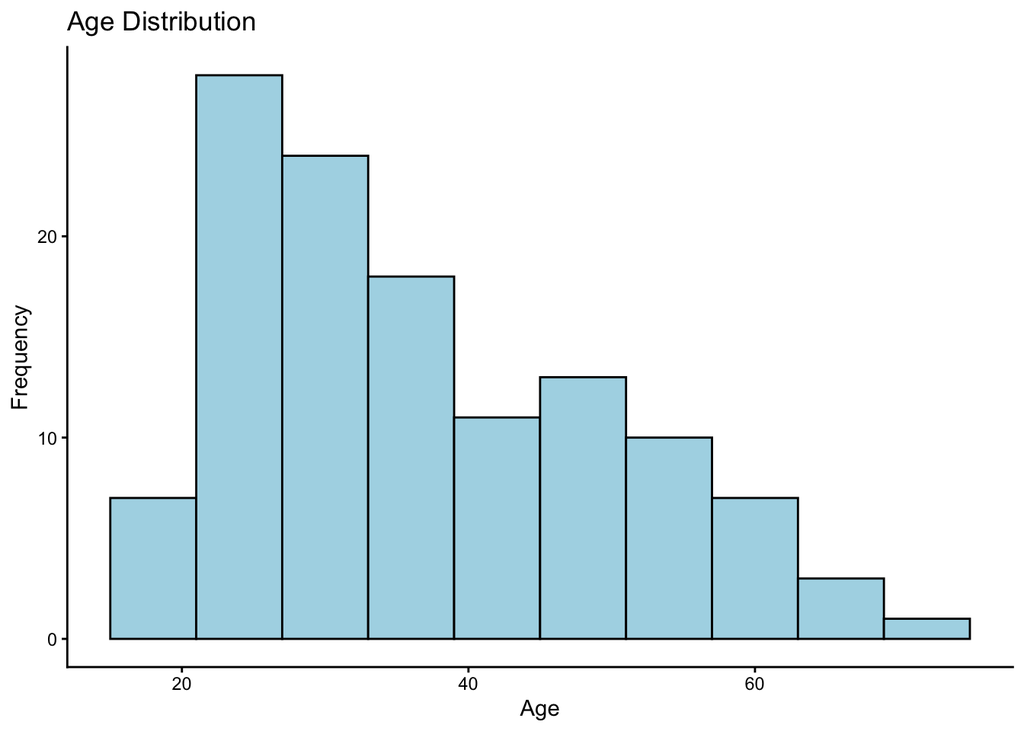

```
This chart has title 'Age Distribution'.
It has x-axis 'Age' with labels 20, 40 and 60.
It has y-axis 'Frequency' with labels 0, 10 and 20.
The chart is a bar chart with 10 vertical bars.
Bar 1 is centered at 18, and length is from 0 to 7.
Bar 2 is centered at 24, and length is from 0 to 28.
Bar 3 is centered at 30, and length is from 0 to 24.
Bar 4 is centered at 36, and length is from 0 to 18.
Bar 5 is centered at 42, and length is from 0 to 11.
Bar 6 is centered at 48, and length is from 0 to 13.
Bar 7 is centered at 54, and length is from 0 to 10.
Bar 8 is centered at 60, and length is from 0 to 7.
Bar 9 is centered at 66, and length is from 0 to 3.
Bar 10 is centered at 72, and length is from 0 to 1.
It has colour set to black.
It has fill set to very light greenish blue.
```

```r
df.demo %>%
    ggplot(aes(x = Age)) +
    geom_histogram(bins = 10, color = "black", fill = "lightblue") +
    labs(x = "Age", y = "Frequency") +
    ggtitle("Age Distribution") +
    theme_classic()
```

```r
df.demo %>%
    tabyl(Gender) %>%
    adorn_totals("row") %>%
    adorn_pct_formatting(digits = 1) %>%
    knitr::kable()
```

| Gender | n | percent |
| --- | --- | --- |
| Man | 10 | 8.2% |
| Woman | 112 | 91.8% |
| Total | 122 | 100.0% |

### 6.2 Study 2

```r
df.demo <- read_csv('data/tworek2016_study2.csv') %>%
  as_tibble() %>%
  select(age, gender, excluded) %>%
  filter(excluded == 0) %>% # filter out excluded participants
  select(-excluded) %>% # exclude the excluded variable
glimpse()
```

```
Rows: 112
Columns: 2
$ age    <dbl> 39, 35, 40, 39, 65, 47, 26, 22, 25, 38, 39, 22, 25, 32, 25, 55,…
$ gender <dbl> 1, 2, 1, 2, 2, 2, 2, 2, 1, 2, 2, 2, 2, 1, 1, 2, 2, 2, 2, 2, 2, …
```

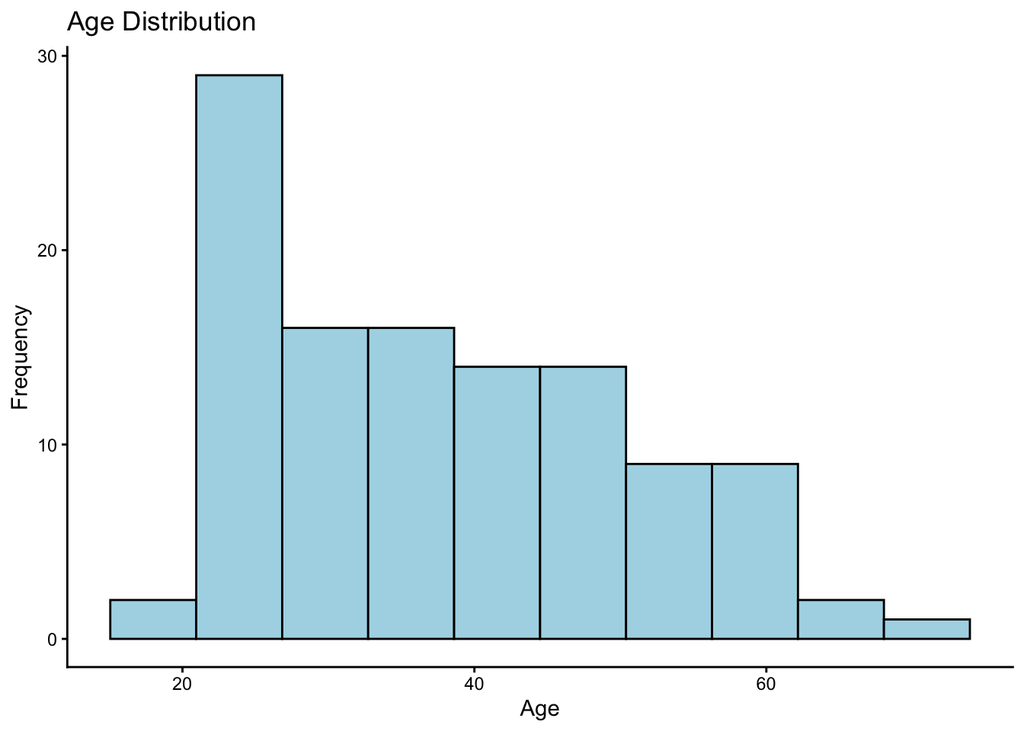

```
This chart has title 'Age Distribution'.
It has x-axis 'Age' with labels 20, 40 and 60.
It has y-axis 'Frequency' with labels 0, 10, 20 and 30.
The chart is a bar chart with 10 vertical bars.
Bar 1 is centered at 18, and length is from 0 to 2.
Bar 2 is centered at 23.89, and length is from 0 to 29.
Bar 3 is centered at 29.78, and length is from 0 to 16.
Bar 4 is centered at 35.67, and length is from 0 to 16.
Bar 5 is centered at 41.56, and length is from 0 to 14.
Bar 6 is centered at 47.44, and length is from 0 to 14.
Bar 7 is centered at 53.33, and length is from 0 to 9.
Bar 8 is centered at 59.22, and length is from 0 to 9.
Bar 9 is centered at 65.11, and length is from 0 to 2.
Bar 10 is centered at 71, and length is from 0 to 1.
It has colour set to black.
It has fill set to very light greenish blue.
```

```r
df.demo %>%
    ggplot(aes(x = age)) +
    geom_histogram(bins = 10, color = "black", fill = "lightblue") +
    labs(x = "Age", y = "Frequency") +
    ggtitle("Age Distribution") +
    theme_classic()
```

```r
df.demo %>%
    tabyl(gender) %>%
    adorn_totals("row") %>%
    adorn_pct_formatting(digits = 1) %>%
    knitr::kable()
```

| gender | n | percent |
| --- | --- | --- |
| 1 | 45 | 40.2% |
| 2 | 67 | 59.8% |
| Total | 112 | 100.0% |

## 7 Bonus Exercise: Reliability Analysis

### 7.1 Study 1

```r
df.items <- read_csv('data/tworek2016_study1.csv') %>%
  as_tibble() %>%
  select(starts_with("ih"), Excluded) %>% # select the 15 items and the Excluded variable
  filter(Excluded == 0) %>% # filter out excluded participants
  select(-ihc1, -ihc2, -Excluded) # exclude the two attention check items and the Excluded variable
glimpse(df.items)
```

```
Rows: 122
Columns: 15
$ ih01stop   <dbl> 9, 3, 7, 5, 8, 8, 4, 6, 8, 5, 8, 6, 8, 7, 6, 1, 8, 5, 7, 6,…
$ ih02beds   <dbl> 9, 6, 8, 3, 6, 7, 4, 4, 8, 5, 8, 5, 8, 4, 6, 1, 6, 7, 9, 7,…
$ ih03diamon <dbl> 9, 7, 6, 3, 6, 8, 5, 5, 4, 5, 8, 1, 7, 6, 6, 1, 1, 5, 8, 5,…
$ ih04dollar <dbl> 8, 1, 6, 5, 2, 6, 4, 1, 4, 5, 4, 1, 7, 3, 5, 1, 2, 3, 6, 7,…
$ ih05chipmu <dbl> 9, 6, 4, 5, 6, 3, 7, 8, 4, 5, 7, 5, 6, 5, 5, 7, 2, 5, 8, 8,…
$ ih06oj     <dbl> 8, 1, 5, 3, 7, 5, 4, 5, 4, 9, 4, 5, 3, 3, 3, 1, 3, 7, 8, 4,…
$ ih07pink   <dbl> 9, 5, 7, 5, 3, 8, 8, 1, 6, 5, 4, 2, 7, 5, 5, 4, 1, 2, 9, 6,…
$ ih08white  <dbl> 9, 5, 8, 5, 3, 9, 5, 5, 6, 2, 6, 5, 4, 3, 7, 3, 7, 4, 9, 6,…
$ ih09black  <dbl> 9, 7, 6, 5, 6, 7, 7, 5, 7, 8, 8, 5, 6, 6, 5, 5, 6, 7, 9, 4,…
$ ih10mint   <dbl> 9, 8, 3, 2, 4, 5, 7, 6, 4, 8, 8, 5, 8, 7, 5, 6, 7, 3, 8, 7,…
$ ih117days  <dbl> 3, 1, 5, 5, 3, 4, 3, 6, 7, 1, 8, 5, 1, 6, 6, 5, 6, 6, 6, 6,…
$ ih12weeken <dbl> 3, 9, 7, 5, 8, 8, 7, 4, 8, 5, 7, 5, 8, 6, 4, 6, 7, 7, 8, 5,…
$ ih13limbs  <dbl> 6, 7, 2, 3, 3, 7, 7, 4, 8, 5, 7, 4, 3, 6, 6, 1, 7, 7, 8, 5,…
$ ih14eyes   <dbl> 9, 8, 6, 5, 7, 7, 3, 5, 8, 9, 6, 5, 6, 6, 8, 1, 7, 7, 9, 7,…
$ ih15sounds <dbl> 6, 6, 7, 5, 7, 7, 4, 7, 6, 4, 7, 5, 6, 5, 6, 1, 6, 7, 9, 6,…
```

```r
ih.keys <- list(ih = seq(1, 15)) # no reverse-coded items

# score the items using the scoreItems() function from the psych package
ih <- scoreItems(
  items = df.items,
  keys = ih.keys,
  totals = FALSE)

ih$alpha # Cronbach's alpha
```

```
             ih
alpha 0.8481784
```

### 7.2 Study 2

```r
df.items <- read_csv('data/tworek2016_study2.csv') %>%
  as_tibble() %>%
  select(starts_with("ext"), starts_with("ih"), excluded) %>%
  filter(excluded == 0) %>% # filter out excluded participants
  select(-ihcatch1, -ihcatch2, -ihav, -extav, -excluded) # exclude the two attention check items and the excluded variable
glimpse(df.items)
```

```
Rows: 112
Columns: 30
$ ext01stop   <dbl> 7, 6, 2, 7, 5, 3, 6, 5, 1, 5, 7, 4, 9, 8, 5, 7, 3, 5, 5, 7…
$ ext02beds   <dbl> 8, 6, 1, 6, 6, 6, 8, 5, 1, 5, 7, 6, 9, 6, 5, 5, 3, 7, 5, 5…
$ ext03diamon <dbl> 7, 6, 3, 6, 7, 6, 8, 6, 9, 5, 4, 9, 9, 8, 5, 8, 3, 8, 5, 7…
$ ext04dollar <dbl> 8, 5, 5, 6, 5, 6, 7, 5, 7, 5, 7, 7, 9, 8, 8, 6, 7, 7, 7, 1…
$ ext05chipmu <dbl> 4, 5, 1, 1, 6, 4, 7, 4, 1, 5, 4, 7, 2, 7, 5, 5, 5, 2, 6, 4…
$ ext06oj     <dbl> 8, 3, 1, 4, 6, 6, 7, 3, 9, 5, 8, 7, 6, 7, 7, 7, 7, 4, 6, 8…
$ ext07pink   <dbl> 5, 4, 2, 8, 8, 4, 9, 5, 9, 5, 7, 8, 4, 8, 5, 6, 3, 9, 2, 7…
$ ext08white  <dbl> 7, 4, 3, 4, 1, 4, 8, 3, 1, 5, 4, 1, 9, 7, 5, 8, 3, 8, 5, 5…
$ ext09black  <dbl> 5, 5, 9, 7, 3, 6, 7, 8, 1, 8, 5, 5, 5, 8, 5, 5, 3, 4, 7, 7…
$ ext10mint   <dbl> 6, 6, 4, 1, 6, 2, 8, 7, 9, 5, 4, 8, 6, 7, 5, 5, 5, 3, 6, 5…
$ ext117days  <dbl> 6, 5, 5, 6, 5, 4, 8, 8, 5, 5, 8, 8, 7, 8, 5, 4, 7, 5, 3, 4…
$ ext12weeken <dbl> 5, 5, 2, 6, 5, 4, 7, 6, 1, 5, 7, 7, 6, 6, 5, 4, 7, 8, 5, 7…
$ ext13limbs  <dbl> 6, 5, 2, 1, 8, 1, 9, 5, 9, 5, 8, 4, 1, 7, 4, 5, 7, 5, 5, 5…
```

[output cut: 17 more lines]

```r
ih.keys <- list(ih = c(-seq(1, 15), seq(16, 30))) # no reverse-coded items

# score the items using the scoreItems() function from the psych package
ih <- scoreItems(
  items = df.items,
  keys = ih.keys,
  totals = FALSE)

ih$alpha # Cronbach's alpha
```

```
             ih
alpha 0.8384305
```